# The Silent Crisis: Neonatal Deaths & the World’s Adolescent Population

## 5 Adolescent Population vs. Neonatal Deaths — Scatterplot

Is there a relationship between a country’s **adolescent population size** and its **neonatal death count**? The scatterplot below, fitted with a linear regression line, suggests a clear **positive association**: countries with larger adolescent populations tend to record higher neonatal deaths. This is partly a scale effect — larger populations produce more births and consequently more deaths — but it also reflects that high-fertility nations with large youth cohorts frequently lack the healthcare infrastructure needed to protect newborns.

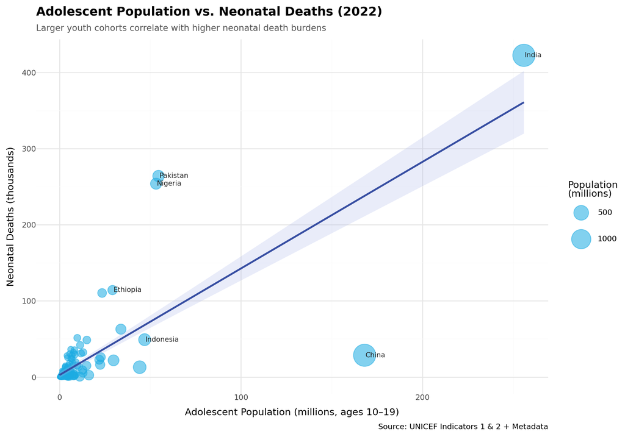

Figure 3: Relationship between adolescent population size and neonatal deaths (2022). Point size reflects total population.

```python
scatter_df = snap_pd.dropna(
    subset=["adol_pop_thousands", "neonatal_deaths", "population"]
).copy()

scatter_df["pop_millions"]  = scatter_df["population"] / 1_000_000
scatter_df["adol_millions"] = scatter_df["adol_pop_thousands"] / 1_000
scatter_df["neo_k"]         = scatter_df["neonatal_deaths"] / 1_000

label_countries = [
    "Nigeria", "India", "Pakistan", "Ethiopia",
    "Democratic Republic of the Congo", "China", "Indonesia"
]
scatter_df["label"] = scatter_df["country"].where(
    scatter_df["country"].isin(label_countries), ""
)

scatter_plot = (
    ggplot(scatter_df, aes(x="adol_millions", y="neo_k",
                           size="pop_millions", label="label"))
    + geom_point(alpha=0.55, color=UNICEF_BLUE)
    + geom_smooth(method="lm", color=UNICEF_DARK, fill="#a8b4e8", alpha=0.25, size=1.2)
    + geom_text(ha="left", nudge_x=0.5, size=8, color="#222222")
    + scale_size_continuous(range=(2, 14), name="Population\n(millions)")
    + labs(
        title="Adolescent Population vs. Neonatal Deaths (2022)",
        subtitle="Larger youth cohorts correlate with higher neonatal death burdens",
        x="Adolescent Population (millions, ages 10–19)",
        y="Neonatal Deaths (thousands)",
        caption="Source: UNICEF Indicators 1 & 2 + Metadata"
    )
    + theme_minimal()
    + theme(
        plot_title=element_text(size=14, weight="bold"),
        plot_subtitle=element_text(size=10, color="#555555"),
        figure_size=(10, 7)
    )
)
scatter_plot
```

## 6 Time-Series: Progress Over Decades

[figure not shown]

```python
top5_countries = snap_pd.nlargest(5, "neonatal_deaths")["country"].tolist()

ts_df = (
    combined
    .filter(pl.col("country").is_in(top5_countries))
    .filter(pl.col("neonatal_deaths").is_not_null())
    .select(["country", "year", "neonatal_deaths"])
    .to_pandas()
)
ts_df["neo_k"] = ts_df["neonatal_deaths"] / 1_000

PALETTE = ["#1CABE2", "#E2231A", "#FFC20E", "#80BD41", "#374EA2"]

ts_plot = (
    ggplot(ts_df, aes(x="year", y="neo_k", color="country"))
    + geom_line(size=1.1)
    + geom_point(size=1.4, alpha=0.7)
    + scale_color_manual(values=PALETTE, name="Country")
    + scale_x_continuous(breaks=list(range(1990, 2025, 5)))
    + labs(
        title="Neonatal Deaths Over Time: Top 5 Burden Countries (1988–2022)",
        subtitle="India shows clear improvement; Nigeria's toll has plateaued at an unacceptably high level",
        x="Year",
        y="Neonatal Deaths (thousands)",
        caption="Source: UNICEF Neonatal Deaths Indicator"
    )
    + theme_minimal()
    + theme(
        plot_title=element_text(size=14, weight="bold"),
        plot_subtitle=element_text(size=10, color="#555555"),
        legend_title=element_text(size=9),
        axis_text_x=element_text(angle=45, ha="right"),
        figure_size=(11, 6)
    )
)
ts_plot
```

## 7 Conclusion

The data paint a picture that is simultaneously hopeful and deeply concerning:

Every neonatal death is preventable with the right interventions — skilled birth attendants, clean facilities, and accessible antenatal care. The world has both the knowledge and the means to close this gap. What is needed is sustained political will and investment.

*Report prepared using UNICEF global indicator data. Visualisations produced with `plotnine` in Python, rendered with Quarto.*